# PA1_template.Rmd

Federico Gonzalez

15/02/2018

## Introduction

##### It is now possible to collect a large amount of data about personal movement using activity monitoring devices such as a Fitbit, Nike Fuelband, or Jawbone Up. These type of devices are part of the “quantified self” movement – a group of enthusiasts who take measurements about themselves regularly to improve their health, to find patterns in their behavior, or because they are tech geeks. But these data remain under-utilized both because the raw data are hard to obtain and there is a lack of statistical methods and software for processing and interpreting the data.

## Data

##### The variables included in this dataset are:

1. steps: Number of steps taking in a 5-minute interval (missing values are coded as NA)
2. date: The date on which the measurement was taken in YYYY-MM-DD format
3. interval: Identifier for the 5-minute interval in which measurement was taken

##### The dataset is stored in a comma-separated-value (CSV) file and there are a total of 17,568 observations in this dataset.

## Loading dependencies

```r
library(ggplot2)
library(dplyr)
```

## Loading and preprocessing the data

```r
#remove all objects
rm(list=ls())

destfile <-  "Activity_Monitoring_Data.zip"

    if (!file.exists(destfile)){
        download.file("https://d396qusza40orc.cloudfront.net/repdata%2Fdata%2Factivity.zip","Activity_Monitoring_Data.zip")
        unzip("Activity_Monitoring_Data.zip")
    }

# Read data
Activity <- read.csv("activity.csv")
Activity$date <- as.Date(as.character(Activity$date))
```

## What is mean total number of steps taken per day?

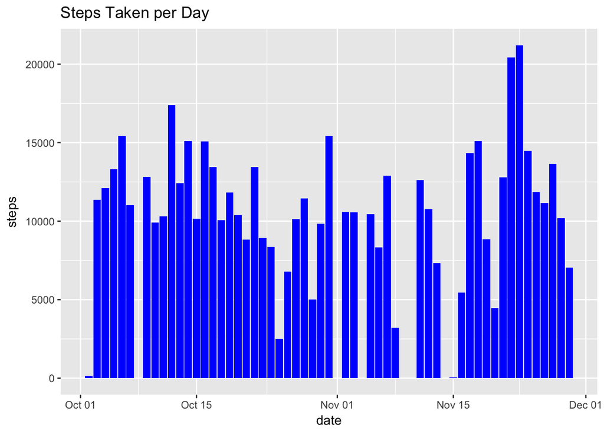

```r
##histogram Steps Taken per day
g <- ggplot(subset(Activity,!is.na(steps)),aes(x=date , y=steps)) + geom_col(fill="blue") + labs(title="Steps Taken per Day")
print(g)
```

```r
##Grouping total steps by date
Activity2 <- Activity[!is.na(Activity$steps),] %>% group_by(date) %>% summarise(steps=sum(steps))

##Calculate mean and median of total number of steps taken     by day
dayMean <- prettyNum(mean(Activity2$steps, na.rm = T), big.mark= ",")
dayMedian <- prettyNum(median(Activity2$steps, na.rm = T), big.mark = ",")
```

##### Steps mean by day is 10,766.19 and steps median is 10,765.

## What is the average daily activity pattern?

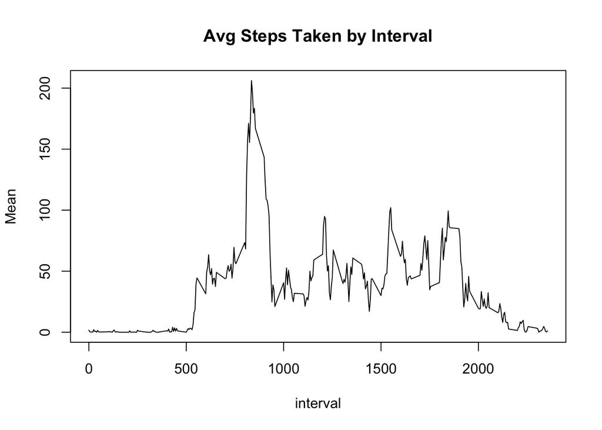

```r
d <- Activity[!is.na(Activity$steps),] %>% group_by(interval) %>% summarise(Mean = mean(steps))
with(d, plot(interval,Mean, type="l", main= "Avg Steps Taken by Interval" ))
```

```r
Maxmean <- d[which.max(d$Mean),]
```

##### Maximum steps in a 5-minute interval is 206.1698113 in the interval 835.

## Imputing missing values

```r
na_count <-as.data.frame(lapply(Activity, function(y) length(which(is.na(y)))))
```

##### Number of NA’s in the dataset is 2304, all NA’s found in the “steps” column.

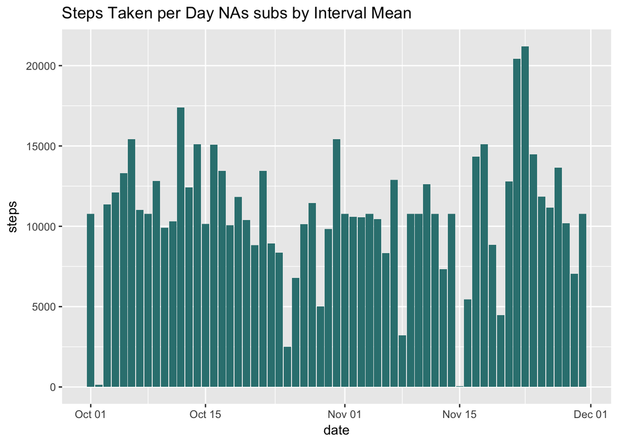

```r
 #Imput missing values as per interval mean
for (i in 1:ncol(Activity)) {
    for (j in which(is.na(Activity[, i]))) {
        Activity[j, i] <- mean(Activity[Activity[, "interval"] == Activity[j, "interval"], i],  na.rm = TRUE)
    }
}

#Plotting data with new dataset
g2 <- ggplot(Activity,aes(x=date , y=steps)) +
    geom_col(fill=rgb(.2,0.5,.5)) +
    labs(title="Steps Taken per Day NAs subs by Interval Mean")

print(g2)
```

```r
#Calculate Mean and Median with new dataset with imputed values
dayMean2 <- format(mean(Activity2$steps, na.rm = T), digits = 1)
dayMedian2 <- format(median(Activity2$steps, na.rm = T),digits = 1)

dif <- as.numeric(dayMean)-as.numeric(dayMean2)
dif2 <- as.numeric(dayMedian) - as.numeric(dayMedian2)
```

## Are there differences in activity patterns between weekdays and weekends?

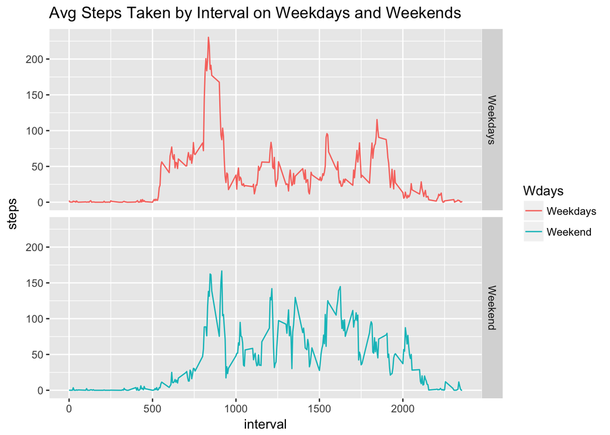

```r
#Create a new factor indicating if its a weekday or weekend
weekenddays <- c("Saturday","Sunday")
Activity$Wdays <- factor(weekdays(Activity$date) %in% weekenddays , levels = c(FALSE,TRUE), labels = c("Weekdays","Weekend"))

#Mean calculation by weekday/interval group
Ac <- Activity %>% group_by(Wdays,interval) %>% summarise(steps = mean(steps))

#Plotting steps taken by interval for weekdays and weekends
g <- ggplot(Ac,aes(interval,steps, colour=Wdays)) +
    geom_line() +facet_grid(Wdays~.) +
    labs(title="Avg Steps Taken by Interval on Weekdays and Weekends")

print(g)
```